# Test a Perceptual Phenomenon

### Analyzing the Stroop Effect

Perform the analysis in the space below. Remember to follow [the instructions](https://docs.google.com/document/d/1-OkpZLjG_kX9J6LIQ5IltsqMzVWjh36QpnP2RYpVdPU/pub?embedded=True) and review the [project rubric](https://review.udacity.com/#!/rubrics/71/view) before submitting. Once you've completed the analysis and write-up, download this file as a PDF or HTML file, upload that PDF/HTML into the workspace here (click on the orange Jupyter icon in the upper left then Upload), then use the Submit Project button at the bottom of this page. This will create a zip file containing both this .ipynb doc and the PDF/HTML doc that will be submitted for your project.

(1) What is the independent variable? What is the dependent variable?

**Independent Variable** : Congruent words or Incongruent words

**Dependent Variable** : Time to read the text

(2) What is an appropriate set of hypotheses for this task? Specify your null and alternative hypotheses, and clearly define any notation used. Justify your choices.

Null hypotheses ($H_{0}$): There is no difference between the average time to read a congruent text and the average time incongruent to read text.

Alternative hypotheses ($H_{1}$): There is difference between the average time to read a congruent text and the average time to read incongruent text.

$H_{0}$ : $\mu_{congruent}$ - $\mu_{incongruent}$ = 0

$H_{1}$ : $\mu_{congruent}$ - $\mu_{incongruent}$ ≠ 0

(3) Report some descriptive statistics regarding this dataset. Include at least one measure of central tendency and at least one measure of variability. The name of the data file is 'stroopdata.csv'.

```python
import pandas as pd
import numpy as np
import matplotlib.pyplot as plt
%matplotlib inline

# load the data

df = pd.read_csv("stroopdata.csv")
df.head()
```

|  | Congruent | Incongruent |
| --- | --- | --- |
| 0 | 12.079 | 19.278 |
| 1 | 16.791 | 18.741 |
| 2 | 9.564 | 21.214 |
| 3 | 8.630 | 15.687 |
| 4 | 14.669 | 22.803 |

```python
# calculate the mean of Congruent and Incongruent time
df.mean()
```

```
Congruent      14.051125
Incongruent    22.015917
dtype: float64
```

```python
# calculate the median of Congruent and Incongruent time
df.median()
```

```
Congruent      14.3565
Incongruent    21.0175
dtype: float64
```

We can see above, the mean of Congruent time is less than the mean of Incongruent time

```python
#calcultate standard deviation of Congruent and Incongruent time
df.std()
```

```
Congruent      3.559358
Incongruent    4.797057
dtype: float64
```

(4) Provide one or two visualizations that show the distribution of the sample data. Write one or two sentences noting what you observe about the plot or plots.

```
Text(0,0.5,'Averge Time (seconds)')
```

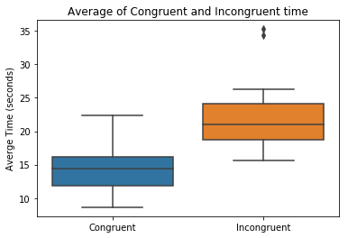

```python
#boxplot shows average of Congruent and Incongruent time
import seaborn as sns

box = sns.boxplot(data=df)

box.set_title('Average of Congruent and Incongruent time')
box.set_ylabel('Averge Time (seconds)')
```

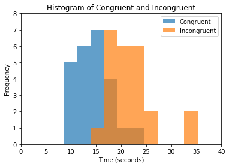

```python
# histigram show Congruent and Incongruent time with the frequency

df.plot(title="Histogram of Congruent and Incongruent", kind='hist', alpha= 0.7, bins=10)
plt.xlabel('Time (seconds)')
size = plt.axis([0,40,0,8])
```

(5) Now, perform the statistical test and report your results. What is your confidence level or Type I error associated with your test? What is your conclusion regarding the hypotheses you set up? Did the results match up with your expectations? **Hint:** Think about what is being measured on each individual, and what statistic best captures how an individual reacts in each environment.

**Sample size** n = 24

**mean difference** = $\Sigma ({\mu_{incongruent}} − {\mu_{congruent}})/n$ = 7.964

**standard deviation** $\sigma$= 4.86

**standard error of the difference** ${\sigma_{difference}} = \sigma/\sqrt n = 4.86/\sqrt 24 = 0.99$

**t-statistic** T = ${\mu_{difference}} /\sigma_{difference}$ = 7.964/0.99 = 8.0207 on 23 degrees of freedom

**t-distribution** with n-1 degrees of freedom (df = 23). Using the t-distribution table to find p-value.

The value of p is < 0.0001. The result is significant at p < 0.05%

**State Results:**

t-statistic > t-critical

so i reject the null hypothesis.

## Conclusion:

We reject the Null Hypothesis (There is no difference between the average time to read a congruent text and the average time incongruent to read text). The result of the statistical tests shows that the mean difference between the two paired observations is significantly different from 0. The results match my expectations.

(6) Optional: What do you think is responsible for the effects observed? Can you think of an alternative or similar task that would result in a similar effect? Some research about the problem will be helpful for thinking about these two questions!